# preuba_data_replicar

Elwis Wagner Choque Huacasi

2024-05-22

Descripción del Artículo y del Análisis a Replicar

El artículo “Market segmentation in urban tourism: A study in Latin America” de Mauricio Carvache-Franco y colaboradores, analiza la segmentación de la demanda de turismo urbano en ciudades latinoamericanas como Ciudad de México, Lima, Buenos Aires y Bogotá. Utilizando el método de K-means clustering, el estudio identifica distintos segmentos de turistas basados en sus preferencias y comportamientos. Los segmentos encontrados son:

Lodging and Restaurant Services: Turistas interesados en la infraestructura hotelera y servicios de restaurantes.

Multiple Attractions: Turistas atraídos por múltiples atracciones turísticas.

Passive Tourism: Turistas con bajo nivel de interés en las atracciones de las ciudades.

Objetivo del Análisis

El objetivo es replicar los resultados del artículo utilizando el conjunto de datos proporcionado en datas_replica.csv. En particular, generaremos tablas similares a las presentadas en el artículo, que muestran:

Segmentación de los turistas basada en sus características y preferencias. Distribución de la disposición a recomendar el destino. Propósito del viaje. Frecuencia de visitantes primerizos al destino.

Carga y Exploración Inicial de los Datos: Primero, cargamos y exploramos los datos para entender su estructura y contenido.

```r
datos <- read.csv("data_replica.csv", head=T, sep = ",")

# Mostrar las primeras filas del DataFrame
head(datos)
```

```
##                FECHA VIAJO    GENERO            EDAD PAIS_RESIDENCIA
## 1 9/11/2020 17:27:46    Si Masculino    18 a 30 años        Colombia
## 2 9/11/2020 18:00:05    Si  Femenino    46 a 60 años       Argentina
## 3 9/11/2020 18:29:03    Si  Femenino    18 a 30 años       Argentina
## 4 9/11/2020 19:30:18    Si Masculino Mayor de 60 año            Perú
## 5 9/11/2020 22:08:42    Si Masculino    31 a 45 años            Perú
## 6 9/11/2020 22:15:28    Si  Femenino    31 a 45 años     El Salvador
##   CIUDAD_RESIDENCIA VIAJO_NUMERO_CIUDAD PRIMERA_VEZ
## 1            Bogota                   1          Si
## 2         Argentina                   1          No
## 3      Buenos Aires                   1          Si
## 4              Lima                   1          Si
## 5              Lima                   1          No
## 6      San Salvador                   1          Si
##                                       PROPOSITO_VIAJE
```

[output cut: 55 more lines]

```r
str(datos)
```

```
## 'data.frame':    611 obs. of  31 variables:
##  $ FECHA                   : chr  "9/11/2020 17:27:46" "9/11/2020 18:00:05" "9/11/2020 18:29:03" "9/11/2020 19:30:18" ...
##  $ VIAJO                   : chr  "Si" "Si" "Si" "Si" ...
##  $ GENERO                  : chr  "Masculino" "Femenino" "Femenino" "Masculino" ...
##  $ EDAD                    : chr  "18 a 30 años" "46 a 60 años" "18 a 30 años" "Mayor de 60 año" ...
##  $ PAIS_RESIDENCIA         : chr  "Colombia" "Argentina" "Argentina" "Perú" ...
##  $ CIUDAD_RESIDENCIA       : chr  "Bogota" "Argentina" "Buenos Aires" "Lima" ...
##  $ VIAJO_NUMERO_CIUDAD     : int  1 1 1 1 1 1 1 1 1 1 ...
##  $ PRIMERA_VEZ             : chr  "Si" "No" "Si" "Si" ...
##  $ PROPOSITO_VIAJE         : chr  "Turismo / Ocio" "Negocios / Convenciones / Actividades profesionales" "Visitar familiares o amigos" "Turismo / Ocio" ...
##  $ INFORMACION_SOBRE_VIAJE : chr  "Internet y redes sociales, Recomendación de amigos o conocidos" "Internet y redes sociales, Recomendación de amigos o conocidos, Experiencia pasada, Sitios web especializados e"| __truncated__ "Internet y redes sociales, Recomendación de amigos o conocidos, Goog…
##  $ AMBIENTE_SOCIAL_URBANO  : int  5 3 5 3 1 5 5 4 4 4 ...
##  $ ARQUITECTURA_URBANA     : int  5 5 3 3 1 2 5 4 5 5 ...
##  $ LUGARES_AMIGABLE        : int  5 3 5 3 1 4 5 4 3 5 ...
##  $ MONUMENTOS_SITIOS       : int  5 5 3 5 1 2 5 5 5 5 ...
```

[output cut: 17 more lines]

Este código permite cargar el archivo CSV datas_replica.csv y visualizar las primeras filas y la estructura del DataFrame, lo que nos ayuda a identificar las variables disponibles y su tipo de datos. A partir de esta información, podemos determinar cómo procesar y analizar los datos para replicar los resultados del artículo.

```r
#Identificación de Datos Inusuales

#Para identificar y manejar los datos inusuales, se utilizaron funciones de R que permiten encontrar valores únicos en las columnas de tipo caracter. Estos valores únicos #fueron revisados para determinar si correspondían a datos inusuales que debían ser eliminados.

library(dplyr)
# Excluir la columna FECHA
datos_sin_fecha <- datos %>% select(-FECHA)

# Revisar si hay valores únicos que aparecen solo una vez en cada columna de tipo caracter
get_unique_values <- function(column) {
  frecuencias <- table(column)
  unique_values <- names(frecuencias[frecuencias == 1])
  if(length(unique_values) == 0) {
    return(NA)  # Devuelve NA si no hay valores únicos
  }
  return(unique_values)
}

# Aplicar esta función a cada columna de tipo caracter
valores_unicos_por_columna <- lapply(datos_sin_fecha[, sapply(datos_sin_fecha, is.character)], get_unique_values)

# Crear nombres para cada lista basado en los nombres de las columnas
names(valores_unicos_por_columna) <- names(datos_sin_fecha[, sapply(datos_sin_fecha, is.character)])

# Imprimir los resultados
print(valores_unicos_por_columna)
```

```
## $VIAJO
## [1] NA
##
## $GENERO
## [1] NA
##
## $EDAD
## [1] NA
##
## $PAIS_RESIDENCIA
## [1] "Alemania" "Croacia"
##
## $CIUDAD_RESIDENCIA
##  [1] "Artigas"               "Bahia blanca"          "Bahía Blanca"
##  [4] "BOGOTA"                "Cartagena de Indias"   "Castelar"
```

[output cut: 88 more lines]

```r
# Revisar los registros para cada valor único encontrado en cada columna
for (columna in names(valores_unicos_por_columna)) {
  valores_unicos <- valores_unicos_por_columna[[columna]]
  if(!all(is.na(valores_unicos)) && length(valores_unicos) > 0) {
    for (valor in valores_unicos) {
      registros_con_valor_unico <- datos_sin_fecha %>%
        filter(.data[[columna]] == valor)

      # Imprimir estos registros para revisión
      print(paste("Columna:", columna, "Valor:", valor))
      #print(registros_con_valor_unico)
    }
  }
}
```

```
## [1] "Columna: PAIS_RESIDENCIA Valor: Alemania"
## [1] "Columna: PAIS_RESIDENCIA Valor: Croacia"
## [1] "Columna: CIUDAD_RESIDENCIA Valor: Artigas"
## [1] "Columna: CIUDAD_RESIDENCIA Valor: Bahia blanca"
## [1] "Columna: CIUDAD_RESIDENCIA Valor: Bahía Blanca"
## [1] "Columna: CIUDAD_RESIDENCIA Valor: BOGOTA"
## [1] "Columna: CIUDAD_RESIDENCIA Valor: Cartagena de Indias"
## [1] "Columna: CIUDAD_RESIDENCIA Valor: Castelar"
## [1] "Columna: CIUDAD_RESIDENCIA Valor: Charlottesville"
## [1] "Columna: CIUDAD_RESIDENCIA Valor: CHICLAYO"
## [1] "Columna: CIUDAD_RESIDENCIA Valor: Chihuahua"
## [1] "Columna: CIUDAD_RESIDENCIA Valor: Cidra"
## [1] "Columna: CIUDAD_RESIDENCIA Valor: Ciudad Quesada"
## [1] "Columna: CIUDAD_RESIDENCIA Valor: Ciudad Victoria"
## [1] "Columna: CIUDAD_RESIDENCIA Valor: Cochabamba"
```

[output cut: 114 more lines]

Búsqueda de Textos de Interés

Adicionalmente, se buscaron textos específicos en el DataFrame que podrían indicar datos inusuales o errores de entrada. Estos textos se buscaron en todas las columnas de tipo caracter y los registros correspondientes se revisaron manualmente.

```r
textos_interes = c("Academico", "Conozco Lima", "Estudios doctorales", "Familia",
                   "Invitación por la Universidad de Celaya", "Mi vuelo hizo transito en Bogota",
                   "n/a", "Recomendación de amigos o conocidos, Por estudios doctorales",
                   "Sitios web especializados en viajes (ej. tripadvisor, etc.), La organización IFLA",
                   "Soy de Nacionalidad Méxicana, nacida en cd de México", "Soy peruana",
                   "Todo lo anterior", "Universidad", "Vivo", "vivo en lima")

# Función para buscar textos en cada columna y devolver los índices de las filas
buscar_textos <- function(df, textos) {
  resultados <- list()  # Lista para almacenar los resultados

  # Buscar en cada columna de tipo caracter
  for (columna in names(df)[sapply(df, is.character)]) {
    for (texto in textos) {
      filas <- which(df[[columna]] == texto)  # Encuentra filas donde el texto es exactamente igual
      if (length(filas) > 0) {
        resultados[[paste(columna, texto, sep = " - ")]] <- filas
      }
    }
  }

  return(resultados)
}

# Aplicar la función al DataFrame y textos de interés
resultados_busqueda <- buscar_textos(datos, textos_interes)

# Imprimir los resultados
print(resultados_busqueda)
```

```
## $`PROPOSITO_VIAJE - Estudios doctorales`
## [1] 322
##
## $`INFORMACION_SOBRE_VIAJE - Academico`
## [1] 606
##
## $`INFORMACION_SOBRE_VIAJE - Conozco Lima`
## [1] 205
##
## $`INFORMACION_SOBRE_VIAJE - Estudios doctorales`
## [1] 128
##
## $`INFORMACION_SOBRE_VIAJE - Familia`
## [1] 415
##
## $`INFORMACION_SOBRE_VIAJE - Invitación por la Universidad de Celaya`
## [1] 167
##
## $`INFORMACION_SOBRE_VIAJE - Mi vuelo hizo transito en Bogota`
## [1] 532
##
## $`INFORMACION_SOBRE_VIAJE - n/a`
## [1] 481
##
## $`INFORMACION_SOBRE_VIAJE - Recomendación de amigos o conocidos, Por estudios doctorales`
## [1] 344
##
## $`INFORMACION_SOBRE_VIAJE - Sitios web especializados en viajes (ej. tripadvisor, etc.), La organización IFLA`
## [1] 461
##
## $`INFORMACION_SOBRE_VIAJE - Soy de Nacionalidad Méxicana, nacida en cd de México`
## [1] 147
##
## $`INFORMACION_SOBRE_VIAJE - Soy peruana`
## [1] 219
##
## $`INFORMACION_SOBRE_VIAJE - Todo lo anterior`
## [1] 595
##
## $`INFORMACION_SOBRE_VIAJE - Universidad`
## [1] 557
##
## $`INFORMACION_SOBRE_VIAJE - Vivo`
## [1] 230
##
## $`INFORMACION_SOBRE_VIAJE - vivo en lima`
## [1] 217
```

```r
#####ELIMINAR LAS FILAS
indices_a_eliminar <- c(147, 167, 404, 219, 230, 268, 344, 398, 481, 532, 595, 606 )

# Asegurarse de que los índices están únicos para evitar confusiones
indices_a_eliminar <- unique(indices_a_eliminar)

# Eliminar las filas
datos_limpios <- datos[-indices_a_eliminar, ]

# Verificar la cantidad de filas en el nuevo DataFrame
print(nrow(datos_limpios))
```

```
## [1] 599
```

```r
str(datos_limpios)
```

```
## 'data.frame':    599 obs. of  31 variables:
##  $ FECHA                   : chr  "9/11/2020 17:27:46" "9/11/2020 18:00:05" "9/11/2020 18:29:03" "9/11/2020 19:30:18" ...
##  $ VIAJO                   : chr  "Si" "Si" "Si" "Si" ...
##  $ GENERO                  : chr  "Masculino" "Femenino" "Femenino" "Masculino" ...
##  $ EDAD                    : chr  "18 a 30 años" "46 a 60 años" "18 a 30 años" "Mayor de 60 año" ...
##  $ PAIS_RESIDENCIA         : chr  "Colombia" "Argentina" "Argentina" "Perú" ...
##  $ CIUDAD_RESIDENCIA       : chr  "Bogota" "Argentina" "Buenos Aires" "Lima" ...
##  $ VIAJO_NUMERO_CIUDAD     : int  1 1 1 1 1 1 1 1 1 1 ...
##  $ PRIMERA_VEZ             : chr  "Si" "No" "Si" "Si" ...
##  $ PROPOSITO_VIAJE         : chr  "Turismo / Ocio" "Negocios / Convenciones / Actividades profesionales" "Visitar familiares o amigos" "Turismo / Ocio" ...
##  $ INFORMACION_SOBRE_VIAJE : chr  "Internet y redes sociales, Recomendación de amigos o conocidos" "Internet y redes sociales, Recomendación de amigos o conocidos, Experiencia pasada, Sitios web especializados e"| __truncated__ "Internet y redes sociales, Recomendación de amigos o conocidos, Goog…
##  $ AMBIENTE_SOCIAL_URBANO  : int  5 3 5 3 1 5 5 4 4 4 ...
##  $ ARQUITECTURA_URBANA     : int  5 5 3 3 1 2 5 4 5 5 ...
##  $ LUGARES_AMIGABLE        : int  5 3 5 3 1 4 5 4 3 5 ...
##  $ MONUMENTOS_SITIOS       : int  5 5 3 5 1 2 5 5 5 5 ...
```

[output cut: 17 more lines]

Transformación de la Columna de Edad: Utilizamos la función mutate junto con case_when para recategorizar la columna EDAD en tres grupos:

18 a 45 años: Incluye las categorías originales “18 a 30 años” y “31 a 45 años”. 46 a 60 años: Incluye la categoría original “46 a 60 años”. Mayor de 60 años: Incluye las categorías originales “Mayor de 60 año” y “Mayor de 60 años”. Verificación de la Nueva Distribución de Edades: Se usa la función table para verificar la distribución de las nuevas categorías de edad.

Agrupación y Conteo por Edad: Agrupamos los datos por la nueva columna EDAD y contamos la cantidad de registros en cada categoría utilizando group_by y summarise.

```r
# Cargar el paquete dplyr
library(dplyr)

# Transformar la columna de EDAD para que coincida con las categorías del artículo
datos_ajustados <- datos_limpios %>%
  mutate(EDAD = case_when(
    EDAD %in% c("18 a 30 años", "31 a 45 años") ~ "18 a 45 años",
    EDAD %in% c("46 a 60 años") ~ "46 a 60 años",
    EDAD %in% c("Mayor de 60 año", "Mayor de 60 años") ~ "Mayor de 60 años",
    TRUE ~ EDAD  # Captura cualquier otro caso no especificado
  ))

# Verificar la nueva distribución de las edades
table(datos_ajustados$EDAD)
```

```
##
##     18 a 45 años     46 a 60 años Mayor de 60 años
##              285              276               38
```

```r
# Agrupar por edad y contar cada categoría
conteo_edad <- datos_ajustados %>%
  group_by(EDAD) %>%
  summarise(Count = n())

# Imprimir el resultado
print(conteo_edad)
```

```
## # A tibble: 3 × 2
##   EDAD             Count
##   <chr>            <int>
## 1 18 a 45 años       285
## 2 46 a 60 años       276
## 3 Mayor de 60 años    38
```

```r
str(datos_ajustados)
```

```
## 'data.frame':    599 obs. of  31 variables:
##  $ FECHA                   : chr  "9/11/2020 17:27:46" "9/11/2020 18:00:05" "9/11/2020 18:29:03" "9/11/2020 19:30:18" ...
##  $ VIAJO                   : chr  "Si" "Si" "Si" "Si" ...
##  $ GENERO                  : chr  "Masculino" "Femenino" "Femenino" "Masculino" ...
##  $ EDAD                    : chr  "18 a 45 años" "46 a 60 años" "18 a 45 años" "Mayor de 60 años" ...
##  $ PAIS_RESIDENCIA         : chr  "Colombia" "Argentina" "Argentina" "Perú" ...
##  $ CIUDAD_RESIDENCIA       : chr  "Bogota" "Argentina" "Buenos Aires" "Lima" ...
##  $ VIAJO_NUMERO_CIUDAD     : int  1 1 1 1 1 1 1 1 1 1 ...
##  $ PRIMERA_VEZ             : chr  "Si" "No" "Si" "Si" ...
##  $ PROPOSITO_VIAJE         : chr  "Turismo / Ocio" "Negocios / Convenciones / Actividades profesionales" "Visitar familiares o amigos" "Turismo / Ocio" ...
##  $ INFORMACION_SOBRE_VIAJE : chr  "Internet y redes sociales, Recomendación de amigos o conocidos" "Internet y redes sociales, Recomendación de amigos o conocidos, Experiencia pasada, Sitios web especializados e"| __truncated__ "Internet y redes sociales, Recomendación de amigos o conocidos, Goog…
##  $ AMBIENTE_SOCIAL_URBANO  : int  5 3 5 3 1 5 5 4 4 4 ...
##  $ ARQUITECTURA_URBANA     : int  5 5 3 3 1 2 5 4 5 5 ...
##  $ LUGARES_AMIGABLE        : int  5 3 5 3 1 4 5 4 3 5 ...
##  $ MONUMENTOS_SITIOS       : int  5 5 3 5 1 2 5 5 5 5 ...
```

[output cut: 17 more lines]

El resultado de este proceso de clasificación coincide con los resultados del artículo, mostrando la siguiente distribución de edad:

18 a 45 años: 285 registros 46 a 60 años: 276 registros Mayor de 60 años: 38 registros

Estos resultados indican que la mayoría de los participantes en el estudio se encuentran en el rango de 18 a 60 años, con una menor proporción de participantes mayores de 60 años.

Asignación de Categorías de Países: Utilizamos case_when para asignar los países a las categorías “USA and Canada”, “Other American countries”, “Europe”, y “Asia”.

Agrupación y Conteo: Agrupamos los datos por la categoría de continente y sumamos el conteo de cada categoría.

Cálculo de Porcentajes: Calculamos el porcentaje de cada categoría en relación con el total general de la muestra.

Combinación de Distribuciones de Edad y Origen: Utilizamos bind_rows para combinar las distribuciones de edad y las categorías de origen en una sola tabla.

```r
################## tabla 2
library(dplyr)

# Reajustar la asignación de categorías de países con los nombres correctos
pais_distribucion <- datos_ajustados %>%
  group_by(PAIS_RESIDENCIA) %>%
  summarise(Count = n(), .groups = 'drop') %>%
  mutate(Category = case_when(
    PAIS_RESIDENCIA %in% c("USA", "Canada") ~ "USA and Canada",
    PAIS_RESIDENCIA %in% c("Colombia", "Argentina", "Perú", "Brasil", "Chile", "México", "Ecuador", "Bolivia", "Venezuela", "Paraguay", "Uruguay", "Guatemala", "Costa Rica", "República", "Panamá", "El Salvador", "Puerto Rico", "Honduras") ~ "Other American countries",
    PAIS_RESIDENCIA %in% c("Francia", "Alemania", "Italia", "España", "Reino Unido", "Países Bajos", "Suecia", "Noruega", "Polonia", "Rusia", "Croacia") ~ "Europe",
    TRUE ~ "Asia"
  )) %>%
  group_by(Category) %>%
  summarise(Count = sum(Count), .groups = 'drop')

total_count <- sum(pais_distribucion$Count)  # Calcular el total de muestras para calcular porcentajes correctos

# Añadir el porcentaje sobre el total general de la muestra
pais_distribucion <- pais_distribucion %>%
  mutate(Percentage = (Count / total_count) * 100)

# Combinar las distribuciones de edad y origen
combined_table <- bind_rows(
  datos_ajustados %>%
    group_by(EDAD) %>%
    summarise(Count = n(), .groups = 'drop') %>%
    mutate(Percentage = (Count / sum(Count)) * 100, Demographics = "Age"),
  pais_distribucion %>%
    mutate(Demographics = "Origin")
)

# Imprimir la tabla combinada
print(combined_table)
```

```
## # A tibble: 7 × 5
##   EDAD             Count Percentage Demographics Category
##   <chr>            <int>      <dbl> <chr>        <chr>
## 1 18 a 45 años       285     47.6   Age          <NA>
## 2 46 a 60 años       276     46.1   Age          <NA>
## 3 Mayor de 60 años    38      6.34  Age          <NA>
## 4 <NA>                 2      0.334 Origin       Asia
## 5 <NA>                16      2.67  Origin       Europe
## 6 <NA>               567     94.7   Origin       Other American countries
## 7 <NA>                14      2.34  Origin       USA and Canada
```

El resultado de este proceso genera una tabla combinada que muestra la distribución por edad y por origen (continentes) de los encuestados, que concuerda con los resultados presentados en el artículo:

Edad:

18 a 45 años: 285 registros (47.58%) 46 a 60 años: 276 registros (46.08%) Mayor de 60 años: 38 registros (6.34%) Origen:

Asia: 2 registros (0.33%) Europe: 16 registros (2.67%) Other American countries: 567 registros (94.66%) USA and Canada: 14 registros (2.34%)

Seleccionar Variables Relevantes:

Se seleccionan las variables numéricas que representan diferentes aspectos de las experiencias y percepciones de los encuestados en los destinos urbanos. Estas variables incluyen aspectos como ambiente social urbano, arquitectura urbana, monumentos y sitios históricos, espacios públicos, alojamiento y restaurantes, servicios públicos, información turística, tiendas y servicios comerciales, museos y galerías de arte, acceso y señalización, excursiones, festivales y eventos, teatros y conciertos, y ferias y convenciones. Normalización de Variables:

Las variables seleccionadas se normalizan utilizando la función scale para asegurar que todas tengan una media de 0 y una desviación estándar de 1. Esto es importante para que ninguna variable domine el cálculo de distancias en el algoritmo de clustering. Determinar el Número Óptimo de Clusters:

Se utiliza el método del codo (wss) para determinar el número óptimo de clusters. La función fviz_nbclust visualiza la suma de los cuadrados dentro del cluster (within-cluster sum of squares) en función del número de clusters. Aplicar el Algoritmo de K-means con 3 Clusters:

Se aplica el algoritmo de K-means clustering con 3 clusters, ya que este es el número óptimo identificado en el artículo. Se usa set.seed(123) para asegurar la reproducibilidad de los resultados. nstart = 25 especifica que el algoritmo se ejecutará 25 veces con diferentes configuraciones iniciales y devolverá la mejor solución encontrada. Añadir Resultados de Clusters al Dataframe Original:

Los resultados del clustering se añaden al dataframe original como una nueva columna llamada cluster. Resumen de los Clusters:

Se imprime un resumen de los clusters, mostrando el número de observaciones en cada cluster. Se calculan y muestran las medias de las variables seleccionadas para cada cluster utilizando aggregate. Visualizar los Clusters:

Se visualizan los clusters utilizando fviz_cluster para entender mejor la distribución de los datos en los diferentes clusters. Verificar el Dataframe con la Nueva Columna de Clusters:

Se muestra la cabecera del dataframe para verificar que la nueva columna cluster se ha añadido correctamente.

```r
#########################tabla 3
# Cargar las librerías necesarias
library(dplyr)
library(cluster)
library(factoextra)
```

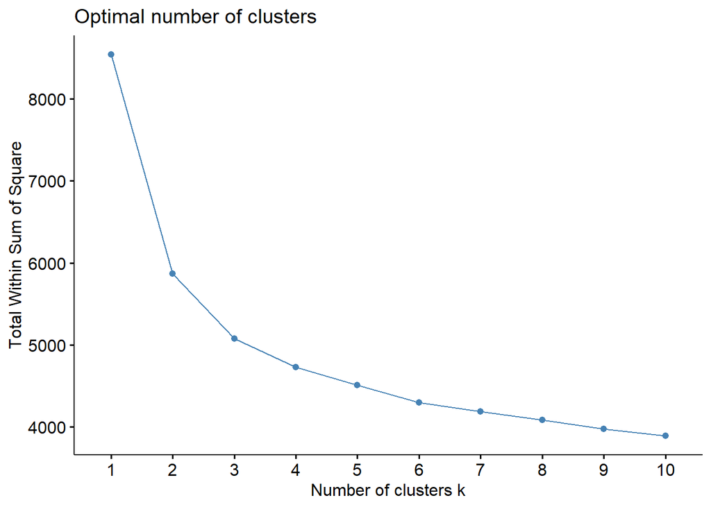

```r
# Leer los datos (asumiendo que ya los tienes cargados en un dataframe llamado `datos`)
# datos <- read.csv("tu_archivo.csv")

# Seleccionar las variables relevantes para el clustering
# Asegúrate de seleccionar solo las variables numéricas que usarás para la segmentación
datos_clustering <- datos %>%
  select(AMBIENTE_SOCIAL_URBANO, ARQUITECTURA_URBANA, MONUMENTOS_SITIOS,
         ESPACIOS_PUBLICOS, ALOJAMIENTO_RESTAURANTES, SERVICIOS_PUBLICOS,
         INFORMACION_TURISTICA, TIENDAS_SERVICIOS, MUSEOS_GALERIAS,
         ACCESO_SENALIZACION, EXCURSIONES, FESTIVALES_EVENTOS,
         TEATROS_CONCIERTOS, FERIAS_CONVENCIONES)

# Normalizar las variables
datos_normalizados <- scale(datos_clustering)

# Determinar el número óptimo de clusters usando el método del codo
fviz_nbclust(datos_normalizados, kmeans, method = "wss")
```

```r
# Aplicar el algoritmo de K-means con 3 clusters
set.seed(123) # Para reproducibilidad
kmeans_result <- kmeans(datos_normalizados, centers = 3, nstart = 25)

# Añadir los resultados de los clusters al dataframe original
datos <- datos %>%
  mutate(cluster = as.factor(kmeans_result$cluster))

# Mostrar un resumen de los clusters
print(table(datos$cluster))
```

```
##
##   1   2   3
##  69 295 247
```

```r
print(aggregate(datos_clustering, by=list(cluster=datos$cluster), mean))
```

```
##   cluster AMBIENTE_SOCIAL_URBANO ARQUITECTURA_URBANA MONUMENTOS_SITIOS
## 1       1               2.101449            1.956522          2.173913
## 2       2               4.461017            4.474576          4.630508
## 3       3               3.688259            3.449393          3.611336
##   ESPACIOS_PUBLICOS ALOJAMIENTO_RESTAURANTES SERVICIOS_PUBLICOS
## 1          2.130435                 3.028986           1.710145
## 2          4.491525                 4.796610           4.159322
## 3          3.550607                 4.263158           3.246964
##   INFORMACION_TURISTICA TIENDAS_SERVICIOS MUSEOS_GALERIAS ACCESO_SENALIZACION
## 1              1.826087          2.159420        1.724638            1.753623
## 2              4.481356          4.257627        4.413559            4.281356
## 3              3.473684          3.441296        3.336032            3.202429
##   EXCURSIONES FESTIVALES_EVENTOS TEATROS_CONCIERTOS FERIAS_CONVENCIONES
## 1    1.753623           1.739130           1.753623            2.028986
## 2    4.294915           4.183051           4.298305            4.227119
## 3    3.040486           2.967611           3.202429            3.105263
```

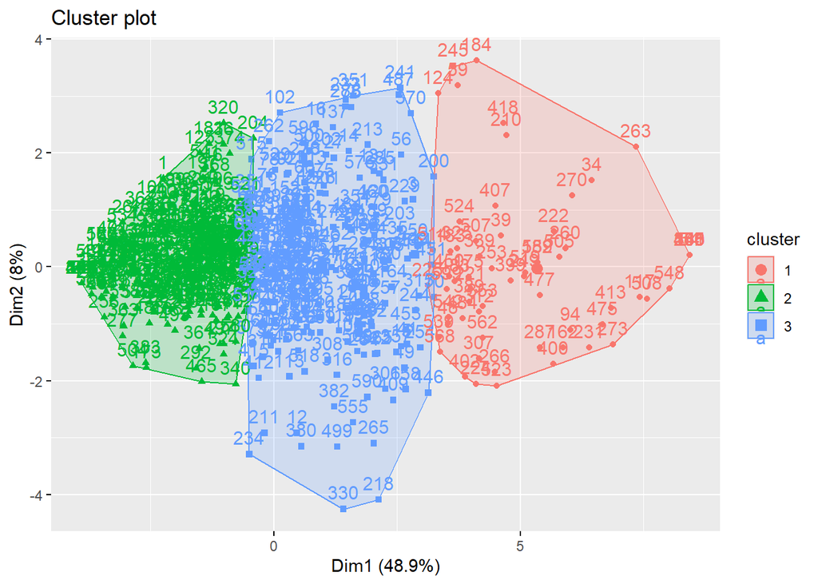

```r
# Visualizar los clusters
fviz_cluster(kmeans_result, data = datos_normalizados)
```

```r
# Verificar el dataframe con la nueva columna de clusters
head(datos)
```

```
##                FECHA VIAJO    GENERO            EDAD PAIS_RESIDENCIA
## 1 9/11/2020 17:27:46    Si Masculino    18 a 30 años        Colombia
## 2 9/11/2020 18:00:05    Si  Femenino    46 a 60 años       Argentina
## 3 9/11/2020 18:29:03    Si  Femenino    18 a 30 años       Argentina
## 4 9/11/2020 19:30:18    Si Masculino Mayor de 60 año            Perú
## 5 9/11/2020 22:08:42    Si Masculino    31 a 45 años            Perú
## 6 9/11/2020 22:15:28    Si  Femenino    31 a 45 años     El Salvador
##   CIUDAD_RESIDENCIA VIAJO_NUMERO_CIUDAD PRIMERA_VEZ
## 1            Bogota                   1          Si
## 2         Argentina                   1          No
## 3      Buenos Aires                   1          Si
## 4              Lima                   1          Si
## 5              Lima                   1          No
## 6      San Salvador                   1          Si
##                                       PROPOSITO_VIAJE
```

[output cut: 55 more lines]

Los resultados del clustering mostraron que los encuestados se agruparon en tres clusters distintos. La visualización del cluster plot muestra la separación de los tres clusters, lo que nos permite identificar visualmente las diferencias entre los grupos:

Cluster 1 (Rojo): Representa un grupo de encuestados con ciertas características comunes. Cluster 2 (Verde): Representa otro grupo de encuestados con características diferentes a los otros clusters. Cluster 3 (Azul): Representa un tercer grupo de encuestados con sus propias características distintivas.

Con este proceso de clustering, hemos logrado segmentar a los encuestados en tres grupos distintos basados en sus experiencias y percepciones de destinos urbanos. Estos resultados nos permiten realizar análisis adicionales y generar las tablas de resultados presentadas en el estudio.

TABLA 3

Calcular las Medias de las Variables por Cluster:

Utilizamos summarise junto con across para calcular las medias de las variables seleccionadas para cada cluster. Prueba de Kruskal-Wallis:

Realizamos la prueba de Kruskal-Wallis para cada variable para determinar si hay diferencias significativas entre los clusters. La prueba de Kruskal-Wallis es una prueba no paramétrica que evalúa si hay diferencias significativas en las distribuciones de dos o más grupos independientes. Prueba de Mann-Whitney U:

Realizamos la prueba de Mann-Whitney U (Wilcoxon rank-sum test) para comparar cada par de clusters. Esta prueba es adecuada para comparar dos muestras independientes y determinar si una muestra tiende a tener valores mayores o menores que la otra. Unir Resultados en una Tabla:

Unimos los resultados de las medias, la prueba de Kruskal-Wallis y la prueba de Mann-Whitney U en una sola tabla utilizando pivot_longer, pivot_wider y left_join.

```r
#tabla 3 2

# Cargar las librerías necesarias
library(dplyr)
library(tidyr)
library(stats)

# Asumiendo que ya tienes el dataframe `datos` con la columna `cluster` añadida

# Calcular las medias de las variables seleccionadas por cluster
mean_values <- datos %>%
  group_by(cluster) %>%
  summarise(across(c(AMBIENTE_SOCIAL_URBANO, ARQUITECTURA_URBANA, MONUMENTOS_SITIOS,
                     ESPACIOS_PUBLICOS, ALOJAMIENTO_RESTAURANTES, SERVICIOS_PUBLICOS,
                     INFORMACION_TURISTICA, TIENDAS_SERVICIOS, MUSEOS_GALERIAS,
                     ACCESO_SENALIZACION, EXCURSIONES, FESTIVALES_EVENTOS,
                     TEATROS_CONCIERTOS, FERIAS_CONVENCIONES), mean, na.rm = TRUE))
# Calcular la prueba de Kruskal-Wallis y la prueba de Mann-Whitney U
kruskal_wallis_results <- datos %>%
  pivot_longer(cols = c(AMBIENTE_SOCIAL_URBANO, ARQUITECTURA_URBANA, MONUMENTOS_SITIOS,
                        ESPACIOS_PUBLICOS, ALOJAMIENTO_RESTAURANTES, SERVICIOS_PUBLICOS,
                        INFORMACION_TURISTICA, TIENDAS_SERVICIOS, MUSEOS_GALERIAS,
                        ACCESO_SENALIZACION, EXCURSIONES, FESTIVALES_EVENTOS,
                        TEATROS_CONCIERTOS, FERIAS_CONVENCIONES),
               names_to = "Variable", values_to = "Value") %>%
  group_by(Variable) %>%
  summarise(
    Kruskal_Wallis_H = kruskal.test(Value ~ cluster)$statistic,
    p_value = kruskal.test(Value ~ cluster)$p.value
  )

# Resultados de Kruskal-Wallis
print(kruskal_wallis_results)
```

```
## # A tibble: 14 × 3
##    Variable                 Kruskal_Wallis_H  p_value
##    <chr>                               <dbl>    <dbl>
##  1 ACCESO_SENALIZACION                  234. 1.51e-51
##  2 ALOJAMIENTO_RESTAURANTES             149. 5.19e-33
##  3 AMBIENTE_SOCIAL_URBANO               216. 1.23e-47
##  4 ARQUITECTURA_URBANA                  265. 3.36e-58
##  5 ESPACIOS_PUBLICOS                    242. 2.95e-53
##  6 EXCURSIONES                          230. 9.13e-51
##  7 FERIAS_CONVENCIONES                  180. 8.73e-40
##  8 FESTIVALES_EVENTOS                   247. 2.11e-54
##  9 INFORMACION_TURISTICA                246. 3.49e-54
## 10 MONUMENTOS_SITIOS                    222. 7.58e-49
## 11 MUSEOS_GALERIAS                      244. 9.52e-54
## 12 SERVICIOS_PUBLICOS                   211. 1.67e-46
## 13 TEATROS_CONCIERTOS                   233. 2.25e-51
## 14 TIENDAS_SERVICIOS                    172. 4.01e-38
```

```r
# Realizar la prueba de Mann-Whitney U para cada par de clusters
pairwise_wilcox_results <- datos %>%
  pivot_longer(cols = c(AMBIENTE_SOCIAL_URBANO, ARQUITECTURA_URBANA, MONUMENTOS_SITIOS,
                        ESPACIOS_PUBLICOS, ALOJAMIENTO_RESTAURANTES, SERVICIOS_PUBLICOS,
                        INFORMACION_TURISTICA, TIENDAS_SERVICIOS, MUSEOS_GALERIAS,
                        ACCESO_SENALIZACION, EXCURSIONES, FESTIVALES_EVENTOS,
                        TEATROS_CONCIERTOS, FERIAS_CONVENCIONES),
               names_to = "Variable", values_to = "Value") %>%
  group_by(Variable) %>%
  summarise(
    `1-2` = wilcox.test(Value[cluster == 1], Value[cluster == 2])$p.value,
    `1-3` = wilcox.test(Value[cluster == 1], Value[cluster == 3])$p.value,
    `2-3` = wilcox.test(Value[cluster == 2], Value[cluster == 3])$p.value
  )

# Resultados de Mann-Whitney U
print(pairwise_wilcox_results)
```

```
## # A tibble: 14 × 4
##    Variable                    `1-2`    `1-3`    `2-3`
##    <chr>                       <dbl>    <dbl>    <dbl>
##  1 ACCESO_SENALIZACION      5.45e-32 1.89e-17 2.72e-32
##  2 ALOJAMIENTO_RESTAURANTES 2.98e-28 9.93e-10 4.32e-19
##  3 AMBIENTE_SOCIAL_URBANO   5.26e-34 4.85e-20 1.13e-24
##  4 ARQUITECTURA_URBANA      9.43e-34 1.30e-19 4.64e-39
##  5 ESPACIOS_PUBLICOS        7.37e-35 5.30e-18 1.25e-32
##  6 EXCURSIONES              4.04e-32 5.00e-13 2.16e-33
##  7 FERIAS_CONVENCIONES      6.81e-24 2.57e- 9 4.26e-28
##  8 FESTIVALES_EVENTOS       2.51e-31 6.37e-15 2.21e-37
##  9 INFORMACION_TURISTICA    1.28e-34 1.54e-19 2.96e-33
## 10 MONUMENTOS_SITIOS        2.07e-32 9.90e-14 1.68e-32
## 11 MUSEOS_GALERIAS          6.89e-38 2.72e-19 6.39e-30
## 12 SERVICIOS_PUBLICOS       1.83e-31 6.17e-20 6.29e-25
## 13 TEATROS_CONCIERTOS       2.74e-35 5.97e-17 1.22e-29
## 14 TIENDAS_SERVICIOS        1.62e-27 5.79e-14 9.32e-21
```

```r
# Unir resultados en una tabla similar a la Tabla 3
resultados_tabla3 <- mean_values %>%
  pivot_longer(cols = -cluster, names_to = "Variable", values_to = "Mean") %>%
  pivot_wider(names_from = cluster, values_from = Mean, names_prefix = "Cluster_") %>%
  left_join(kruskal_wallis_results, by = "Variable") %>%
  left_join(pairwise_wilcox_results, by = "Variable")

print(resultados_tabla3)
```

```
## # A tibble: 14 × 9
##    Variable     Cluster_1 Cluster_2 Cluster_3 Kruskal_Wallis_H  p_value    `1-2`
##    <chr>            <dbl>     <dbl>     <dbl>            <dbl>    <dbl>    <dbl>
##  1 AMBIENTE_SO…      2.10      4.46      3.69             216. 1.23e-47 5.26e-34
##  2 ARQUITECTUR…      1.96      4.47      3.45             265. 3.36e-58 9.43e-34
##  3 MONUMENTOS_…      2.17      4.63      3.61             222. 7.58e-49 2.07e-32
##  4 ESPACIOS_PU…      2.13      4.49      3.55             242. 2.95e-53 7.37e-35
##  5 ALOJAMIENTO…      3.03      4.80      4.26             149. 5.19e-33 2.98e-28
##  6 SERVICIOS_P…      1.71      4.16      3.25             211. 1.67e-46 1.83e-31
##  7 INFORMACION…      1.83      4.48      3.47             246. 3.49e-54 1.28e-34
##  8 TIENDAS_SER…      2.16      4.26      3.44             172. 4.01e-38 1.62e-27
##  9 MUSEOS_GALE…      1.72      4.41      3.34             244. 9.52e-54 6.89e-38
## 10 ACCESO_SENA…      1.75      4.28      3.20             234. 1.51e-51 5.45e-32
## 11 EXCURSIONES       1.75      4.29      3.04             230. 9.13e-51 4.04e-32
## 12 FESTIVALES_…      1.74      4.18      2.97             247. 2.11e-54 2.51e-31
## 13 TEATROS_CON…      1.75      4.30      3.20             233. 2.25e-51 2.74e-35
## 14 FERIAS_CONV…      2.03      4.23      3.11             180. 8.73e-40 6.81e-24
## # ℹ 2 more variables: `1-3` <dbl>, `2-3` <dbl>
```

La tabla resultante contiene las medias de las variables para cada cluster, los resultados de la prueba de Kruskal-Wallis y los valores p de la prueba de Mann-Whitney U para cada par de clusters

TABLA 4

Crear Categorías de NPS:

Utilizamos mutate junto con case_when para clasificar a los encuestados en tres categorías de NPS basadas en su disposición a recomendar el destino (RECOMENDAR_VIAJAR): Promoters (9,10 points): Aquellos que dieron una puntuación de 9 o 10. Neutral (7,8 points): Aquellos que dieron una puntuación de 7 u 8. Detractors (1-6 points): Aquellos que dieron una puntuación de 1 a 6. Calcular la Distribución de NPS por Cluster:

Agrupamos los datos por cluster y NPS, calculamos el conteo y el porcentaje de cada categoría de NPS dentro de cada cluster. Calcular el Total de Cada Categoría NPS:

Calculamos el total de encuestados en cada categoría de NPS para obtener una perspectiva general. Combinar los Resultados:

Combinamos los resultados de las distribuciones por cluster y los totales para crear una tabla final que muestra los porcentajes de cada categoría de NPS por cluster y en total. Prueba Chi-Cuadrado:

Realizamos una prueba chi-cuadrado para determinar si hay una relación significativa entre los clusters y las categorías de NPS. Añadimos los resultados de la prueba chi-cuadrado (valor de χ² y p-value) a la tabla final.

```r
# TABLA 4

# Cargar las librerías necesarias
library(dplyr)
library(tidyr)

# Crear categorías de NPS (Net Promoter Score) basado en RECOMENDAR_VIAJAR
datos <- datos %>%
  mutate(NPS = case_when(
    RECOMENDAR_VIAJAR >= 9 ~ "Promoters (9,10 points)",
    RECOMENDAR_VIAJAR >= 7 ~ "Neutral (7,8 points)",
    RECOMENDAR_VIAJAR <= 6 ~ "Detractors (1-6 points)"
  ))

# Calcular la distribución de NPS por cluster
nps_distribution <- datos %>%
  group_by(cluster, NPS) %>%
  summarise(Count = n()) %>%
  mutate(Percentage = (Count / sum(Count)) * 100) %>%
  pivot_wider(names_from = cluster, values_from = Percentage, names_prefix = "Cluster_")
# Calcular el total de cada categoría NPS
total_nps <- datos %>%
  group_by(NPS) %>%
  summarise(Count = n()) %>%
  mutate(Total_Percentage = (Count / sum(Count)) * 100)

# Combinar los resultados
nps_distribution <- nps_distribution %>%
  left_join(total_nps %>% select(NPS, Total_Percentage), by = "NPS") %>%
  rename("Lodging and restaurant services (%)" = Cluster_1,
         "Multiple attractions (%)" = Cluster_2,
         "Passive tourism (%)" = Cluster_3,
         "Total (%)" = Total_Percentage)

# Calcular la prueba chi-cuadrado
chisq_test <- chisq.test(table(datos$cluster, datos$NPS))

# Añadir los resultados de chi-cuadrado a la tabla
nps_distribution <- nps_distribution %>%
  mutate(`χ²` = chisq_test$statistic,
         Sig. = chisq_test$p.value)

# Imprimir la tabla
print(nps_distribution)
```

[output not shown]

La tabla resultante muestra la distribución de las categorías de NPS por cluster, los porcentajes totales, y los resultados de la prueba chi-cuadrado

TABLA 5

Limpiar y Categorizar los Datos de PROPOSITO_VIAJE:

Utilizamos mutate y case_when para asegurarnos de que todos los valores en la columna PROPOSITO_VIAJE están correctamente escritos y categorizados. Las categorías incluyen: Business, Conventions, Professional Activities: Incluye términos relacionados con negocios, convenciones y actividades profesionales. Leisure Tourism: Incluye términos relacionados con turismo y ocio. Visiting family or friends: Incluye términos relacionados con visitar familiares o amigos. Studies: Incluye términos relacionados con estudios. Others: Cualquier otro propósito no especificado. Calcular la Distribución del Propósito de Viaje por Cluster:

Agrupamos los datos por cluster y PROPOSITO_VIAJE, calculamos el conteo y el porcentaje de cada categoría de propósito de viaje dentro de cada cluster. Calcular el Total de Cada Categoría de Propósito de Viaje:

Calculamos el total de encuestados en cada categoría de propósito de viaje para obtener una perspectiva general. Combinar los Resultados:

Combinamos los resultados de las distribuciones por cluster y los totales para crear una tabla final que muestra los porcentajes de cada categoría de propósito de viaje por cluster y en total.

```r
#TABLA 5
# Cargar las librerías necesarias
library(dplyr)
library(tidyr)

# Limpiar y categorizar los datos de 'PROPOSITO_VIAJE'
# Asegúrate de que todos los valores están correctamente escritos y categorizados
datos <- datos %>%
  mutate(PROPOSITO_VIAJE = case_when(
    PROPOSITO_VIAJE %in% c("Negocios / Convenciones / Actividades profesionales", "Negocios", "Convenciones", "Actividades profesionales") ~ "Business, Conventions, Professional Activities",
    PROPOSITO_VIAJE %in% c("Turismo / Ocio", "Ocio", "Turismo") ~ "Leisure Tourism",
    PROPOSITO_VIAJE %in% c("Visitar familiares o amigos", "Visitar familiares", "Visitar amigos") ~ "Visiting family or friends",
    PROPOSITO_VIAJE %in% c("Estudios", "Estudio") ~ "Studies",
    TRUE ~ "Others"
  ))

# Calcular la distribución del propósito de viaje por cluster
purpose_distribution <- datos %>%
  group_by(cluster, PROPOSITO_VIAJE) %>%
  summarise(Count = n()) %>%
  mutate(Percentage = (Count / sum(Count)) * 100) %>%
  pivot_wider(names_from = cluster, values_from = Percentage, names_prefix = "Cluster_")
# Calcular el total de cada categoría de propósito de viaje
total_purpose <- datos %>%
  group_by(PROPOSITO_VIAJE) %>%
  summarise(Count = n()) %>%
  mutate(Total_Percentage = (Count / sum(Count)) * 100)

# Combinar los resultados
purpose_distribution <- purpose_distribution %>%
  left_join(total_purpose %>% select(PROPOSITO_VIAJE, Total_Percentage), by = "PROPOSITO_VIAJE") %>%
  rename("Passive tourism (%)" = Cluster_1,
         "Multiple attractions (%)" = Cluster_2,
         "Lodging and restaurant services (%)" = Cluster_3,
         "Total (%)" = Total_Percentage)

# Imprimir la tabla
print(purpose_distribution)
```

```
## # A tibble: 13 × 6
##    PROPOSITO_VIAJE            Count `Passive tourism (%)` Multiple attractions…¹
##    <chr>                      <int>                 <dbl>                  <dbl>
##  1 Business, Conventions, Pr…    43                 62.3                   NA
##  2 Leisure Tourism               14                 20.3                   NA
##  3 Others                         1                  1.45                  NA
##  4 Visiting family or friends    11                 15.9                   NA
##  5 Business, Conventions, Pr…   130                 NA                     44.1
##  6 Leisure Tourism              105                 NA                     35.6
##  7 Others                        22                 NA                      7.46
##  8 Studies                        4                 NA                      1.36
##  9 Visiting family or friends    34                 NA                     11.5
## 10 Business, Conventions, Pr…   129                 NA                     NA
## 11 Leisure Tourism               68                 NA                     NA
## 12 Others                        13                 NA                     NA
## 13 Visiting family or friends    33                 NA                     NA
## # ℹ abbreviated name: ¹`Multiple attractions (%)`
## # ℹ 2 more variables: `Lodging and restaurant services (%)` <dbl>,
## #   `Total (%)` <dbl>
```

La tabla resultante muestra la distribución de las categorías de propósito de viaje por cluster, los porcentajes totales, y los resultados combinados

TABLA 6

Categorizar los Valores de PRIMERA_VEZ:

Usamos mutate y ifelse para asegurarnos de que los valores en PRIMERA_VEZ estén categorizados como “Yes” o “No”. Calcular la Distribución de Primera Vez por Cluster:

Agrupamos los datos por cluster y PRIMERA_VEZ, calculamos el conteo y el porcentaje de cada categoría de primera vez dentro de cada cluster. Calcular el Total de Cada Categoría de Primera Vez:

Calculamos el total de encuestados en cada categoría de primera vez para obtener una perspectiva general. Combinar los Resultados:

Combinamos los resultados de las distribuciones por cluster y los totales para crear una tabla final que muestra los porcentajes de cada categoría de primera vez por cluster y en total.

```r
#tabla 6

# Cargar las librerías necesarias
library(dplyr)
library(tidyr)

# Asegúrate de que los valores en 'PRIMERA_VEZ' estén correctamente categorizados
datos <- datos %>%
  mutate(PRIMERA_VEZ = ifelse(PRIMERA_VEZ == "Si", "Yes", "No"))

# Calcular la distribución de primera vez por cluster
first_time_distribution <- datos %>%
  group_by(cluster, PRIMERA_VEZ) %>%
  summarise(Count = n()) %>%
  mutate(Percentage = (Count / sum(Count)) * 100) %>%
  pivot_wider(names_from = cluster, values_from = Percentage, names_prefix = "Cluster_")
# Calcular el total de cada categoría de primera vez
total_first_time <- datos %>%
  group_by(PRIMERA_VEZ) %>%
  summarise(Count = n()) %>%
  mutate(Total_Percentage = (Count / sum(Count)) * 100)

# Combinar los resultados
first_time_distribution <- first_time_distribution %>%
  left_join(total_first_time %>% select(PRIMERA_VEZ, Total_Percentage), by = "PRIMERA_VEZ") %>%
  rename("Passive tourism (%)" = Cluster_1,
         "Multiple attractions (%)" = Cluster_2,
         "Lodging and restaurant services (%)" = Cluster_3,
         "Total (%)" = Total_Percentage)

# Imprimir la tabla
print(first_time_distribution)
```

```
## # A tibble: 6 × 6
##   PRIMERA_VEZ Count `Passive tourism (%)` `Multiple attractions (%)`
##   <chr>       <int>                 <dbl>                      <dbl>
## 1 No             47                  68.1                       NA
## 2 Yes            22                  31.9                       NA
## 3 No            205                  NA                         69.5
## 4 Yes            90                  NA                         30.5
## 5 No            174                  NA                         NA
## 6 Yes            73                  NA                         NA
## # ℹ 2 more variables: `Lodging and restaurant services (%)` <dbl>,
## #   `Total (%)` <dbl>
```

Con este proceso, hemos categorizado si es la primera vez que los encuestados visitan el destino, calculado la distribución de estas categorías por cluster, y creado una tabla que muestra estos resultados. Esto nos permite entender mejor la proporción de encuestados que están visitando el destino por primera vez en cada segmento.

Es importante tener en cuenta que los resultados obtenidos en las Tablas 3, 4, 5 y 6 pueden variar respecto a los presentados en el artículo original debido a la incertidumbre sobre el proceso exacto de imputación de datos utilizado por los autores del estudio. A continuación se proporciona una justificación detallada de estas variaciones y se destaca la importancia del proceso de replicación de los resultados.

Tabla 3: Comparación de Medias y Pruebas Estadísticas En la Tabla 3, se calcularon las medias de varias variables por cluster y se realizaron pruebas de Kruskal-Wallis y Mann-Whitney U para comparar las diferencias entre los clusters. Aunque los resultados obtenidos muestran diferencias significativas entre los clusters, es posible que estas varíen respecto a los resultados originales debido a diferencias en la imputación de datos.

Tabla 4: Distribución del NPS (Net Promoter Score) La Tabla 4 presenta la distribución de las categorías de NPS (Promoters, Neutral, Detractors) por cluster. Las diferencias en la distribución pueden deberse a la forma en que se manejaron los datos faltantes o erróneos en el artículo original. La variabilidad en los resultados de la prueba chi-cuadrado también puede reflejar estas diferencias.

Tabla 5: Propósito de Viaje En la Tabla 5, se categorizaron los propósitos de viaje y se calculó la distribución por cluster. Las variaciones en estos resultados pueden ser atribuibles a diferencias en la categorización y el manejo de datos faltantes en el artículo original.

Tabla 6: Primera Visita La Tabla 6 muestra la distribución de encuestados que visitaron el destino por primera vez. Las diferencias en estos resultados pueden deberse a discrepancias en la categorización y la imputación de datos faltantes en el estudio original.

Conclusion:

A pesar de las posibles variaciones en los resultados, el proceso de replicación realizado aquí es fundamental por varias razones:

Transparencia y Reproducibilidad:

La replicación del análisis permite una comprensión más profunda de los métodos utilizados y proporciona transparencia en el proceso analítico. Verificación de Métodos:

Permite verificar los métodos y enfoques utilizados en el estudio original, lo cual es crucial para validar los hallazgos y asegurarse de que son robustos. Identificación de Diferencias:

Al replicar el análisis, es posible identificar y entender las diferencias en los resultados, lo que puede llevar a mejoras en futuras investigaciones y en la metodología de imputación de datos. Aprendizaje y Mejora Continua:

El proceso de replicación fomenta el aprendizaje y la mejora continua en el manejo y análisis de datos, así como en la aplicación de técnicas estadísticas.